# Linear Regression

## Introduction and Motivation

- **Recap of Day 9:**
  - Introduced the **statistical learning framework**: finding a function \(f\) to model \(Y = f(X) + \epsilon\)
  - Distinguished between **supervised** (labeled \(Y\)) and **unsupervised** (no \(Y\)) learning
  - Contrasted **regression** (quantitative \(Y\)) with **classification** (categorical \(Y\))
  - Discussed the tradeoff between **model flexibility** and **interpretability**
- **Today’s Transition:**
  - Linear regression is our **first concrete supervised learning method**
  - It’s a **regression technique** for quantitative outcomes (e.g., mpg, price, test scores)
  - As a **less flexible model**, it prioritizes interpretability—we can clearly explain relationships
  - We’ll learn how to actually **estimate** \(f\) using the least squares approach
- **Real-World Applications:**
  - Predict sales from advertising spend
  - Estimate exam scores from study hours
  - Forecast housing prices from property features

## Plot the Data and Motivation

- Motivation: Understand how car weight affects fuel efficiency and introduce **linear regression**.

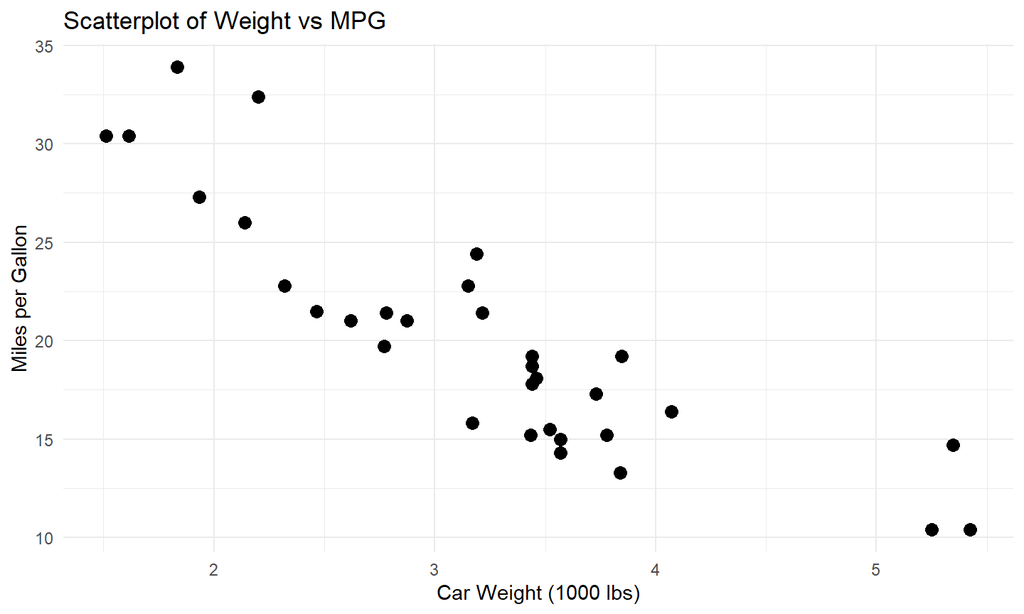

## Why Fit a Model

- Provides a **mathematical summary** of the relationship between variables.
  - Example: Summarizing how car weight predicts fuel efficiency.
- Enables us to:
  - Quantify effects
    - Example: Each 1000 lbs of weight reduces mpg by 5.
  - Make **predictions**
    - Example: Predict mpg for a car weighing 3,000 lbs.
  - Test **hypotheses**
    - Example: Engine size effect on fuel efficiency.
  - Simplify complex data
    - Example: Reduce multiple car features to a single predictive equation.

## Introducing the Line of Best Fit

- Line that summarizes relationship between two variables.
- General form: \(Y = \beta_0 + \beta_1 X + \epsilon\)
  - \(Y\): dependent variable (mpg)
  - \(X\): independent variable (weight)
  - \(\beta_0\): intercept
  - \(\beta_1\): slope
  - \(\epsilon\): error term
- Goal: find line that best represents the data.

## What Does “Best Fit” Mean

- Line should be as close as possible to all data points.
- Use **residuals**: \(e_i = y_i - \hat{y}_i\)
  - \(y_i\): observed value
  - \(\hat{y}_i\): predicted value (denoted with a hat)
- Minimize sum of squared residuals (Least Squares)
  - \(\sum (y_i - \hat{y}_i)^2\)
  - why squared?
  - why the sum?

## Visualizing Fit with Residuals

- Why do we take the sum of squared residuals?

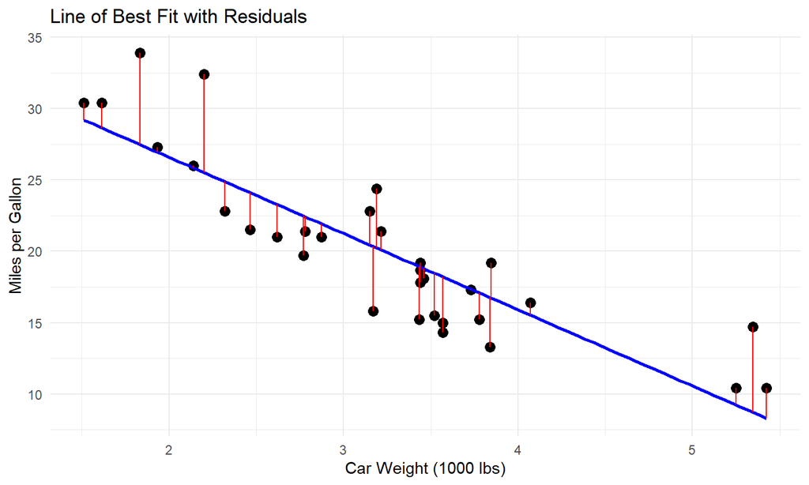

## Least Squares Solution

- Goal: choose \(\beta_0\) and \(\beta_1\) that minimize the sum of squared residuals
- Residual form: minimize \(\sum (y_i - \hat{y}_i)^2\)
- Substitute model: minimize \(\sum (y_i - (\beta_0 + \beta_1 x_i))^2\)
- Function of \(\beta_0\) and \(\beta_1\)
- Take partial derivatives w.r.t \(\beta_0\) and \(\beta_1\), set them to zero → **normal equations**
- Solving gives least squares estimates \(\hat{\beta}_0\) and \(\hat{\beta}_1\)
- Minimization ensures residuals are as small as possible in squared sense
- Solution: \(\beta_0=37.29\), \(\beta_1=-5.34\)

## Parameter confidence

- **Motivation:** When we estimate coefficients, we want to understand not just the number but how reliable it is.
  - Without these metrics, we could make predictions or claims that are misleading.
  - SE, p-values, and significance codes tell us how much confidence we can have in each coefficient.
- **Standard Error**
  - Measures variability of coefficient estimates.
  - Smaller SE → more precise estimates.
  - Appears in the *Std. Error* column of `summary(lm)`.
- **p-values**
  - Probability of observing an effect as extreme if null hypothesis were true.
  - Small p-values (< 0.05) → reject null.
  - In regression: tests if coefficient ≠ 0.
- **Significance Codes**
  - R uses `***`, `**`, `*`, `.` to indicate significance levels.
  - `***`: p < 0.001, `**`: p < 0.01, `*`: p < 0.05, `.`: p < 0.1.
  - Quick visual cue for which coefficients are most trustworthy.

## R-squared

- **R-squared**
  - Proportion of variance explained by model (0–1).
  - Closer to 1 → better fit.
  - Adjusted R² accounts for number of predictors.

## Estimating the OLS Model in R

```r
fit <- lm(mpg ~ wt, data = mtcars)
summary(fit)
```

```
##
## Call:
## lm(formula = mpg ~ wt, data = mtcars)
##
## Residuals:
##     Min      1Q  Median      3Q     Max
## -4.5432 -2.3647 -0.1252  1.4096  6.8727
##
## Coefficients:
##             Estimate Std. Error t value Pr(>|t|)
## (Intercept)  37.2851     1.8776  19.858  < 2e-16 ***
## wt           -5.3445     0.5591  -9.559 1.29e-10 ***
## ---
## Signif. codes:  0 '***' 0.001 '**' 0.01 '*' 0.05 '.' 0.1 ' ' 1
##
## Residual standard error: 3.046 on 30 degrees of freedom
## Multiple R-squared:  0.7528, Adjusted R-squared:  0.7446
## F-statistic: 91.38 on 1 and 30 DF,  p-value: 1.294e-10
```

## Confidence Intervals

- We can use the standard errors to construct **confidence intervals**
- For each parameter, 95% CI = estimate ± (critical value) × SE
- **Critical values** account for uncertainty in our estimates:
  - Come from the t-distribution (similar to normal, but with heavier tails)
  - Heavier tails mean we need wider intervals to be confident with small samples
  - Depend on confidence level (90%, 95%, 99%) and sample size
  - Common critical values: ~1.96 for 95% CI (large samples), ~2.58 for 99% CI
- In R, use `confint()` to compute for each parameter:

```
##                 2.5 %    97.5 %
## (Intercept) 33.450500 41.119753
## wt          -6.486308 -4.202635
```

- **Interpreting the output:**
  - Two columns: 2.5% and 97.5% (the lower and upper bounds)
  - We’re 95% confident the true parameter value falls within this range
  - If the interval doesn’t include 0, the predictor is statistically significant

## Predicting Values

- We can also use the model to predict values outside of our dataset
- Prediction formula: \(\hat{y} = \beta_0 + \beta_1 x\)
- In R, use `predict()` with new data to get predicted values:

```r
newdata <- data.frame(wt=c(2.5, 3, 3.5))
predict(fit, newdata)
```

```
##        1        2        3
## 23.92395 21.25171 18.57948
```

- Output: predicted mpg values for given weights
- Coefficients represent:
  - Intercept: baseline mpg when wt=0
  - Slope: change in mpg for each 1000 lb increase
- Allows estimating mpg for new cars not in the dataset

## Assumptions of Linear Regression

- **Linearity**: relationship between X and Y is linear
  - Why: a straight line can accurately capture the true relationship between variables.
  - Violation example: Modeling exponential growth (e.g., population) with a straight line leads to poor predictions at extremes.
- **Errors uncorrelated with X**: residuals are not systematically related to predictor
  - Why: ensures coefficient estimates are unbiased and capture the true relationship.
  - Violation example: Studying education’s effect on income but omitting ability—ability affects both education and income, biasing the education coefficient upward.
- **Homoscedasticity**: constant variance of residuals
  - Why: guarantees that standard errors and confidence intervals reflect true variability.
  - Violation example: Income prediction where high earners show more variability; confidence intervals become unreliable.

## Sensitivity to Outliers

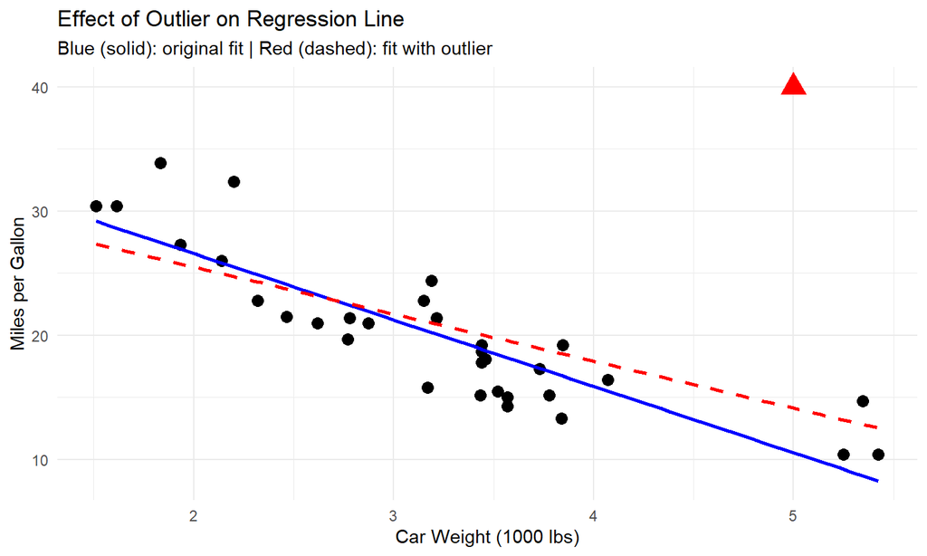

## Why Outliers Matter

- **Influential points** can dramatically change the regression line
  - Single extreme observation pulls the line toward it
  - Changes slope and intercept estimates
  - Can reverse or mask true relationships
- **What to do:**
  - Investigate outliers—are they errors or legitimate extreme values?
  - Consider alternative methods that down-weight extreme points (e.g., weighted regression, quantile regression)
  - Report sensitivity of results to influential points
  - Remove outliers only if they’re data entry errors or clearly invalid

## Wrap-up

- **Key Takeaways:**
  - Linear regression models relationships by fitting a line that minimizes squared residuals
  - Coefficients tell us the direction and magnitude of relationships
  - R-squared, p-values, and confidence intervals help assess model quality
  - Critical assumptions: linearity, uncorrelated errors, and homoscedasticity
- **When to Use Linear Regression:**
  - Relationships appear roughly linear
  - Need interpretable results
  - Want to quantify effects or make predictions
- **Limitations to Remember:**
  - Assumes linear relationships—poor fit for curves or thresholds
  - Sensitive to outliers and influential points
  - Violations of assumptions can lead to biased or unreliable results